# UNICEF Report: Children’s Access to Antiretroviral Treatment (ART)

- Show All Code
- Hide All Code
- View Source

Author

Ronan

Published

April 7, 2025

## Introduction

The global HIV/AIDS epidemic continues to pose substantial public health challenges, with pediatric cases representing a particularly vulnerable population. Despite significant advancements in antiretroviral therapy (ART), access to treatment for children aged 0-14 years remains uneven across regions, reflecting persistent socioeconomic and healthcare disparities. This report critically examines the current state of pediatric ART coverage worldwide, with particular attention to the intersection between economic development and treatment accessibility. This study contributes to ongoing discussions about achieving universal health coverage and meeting Sustainable Development Goal targets for HIV/AIDS management in vulnerable demographic groups.

## Data Analysis

### World Map of ART Access for Children

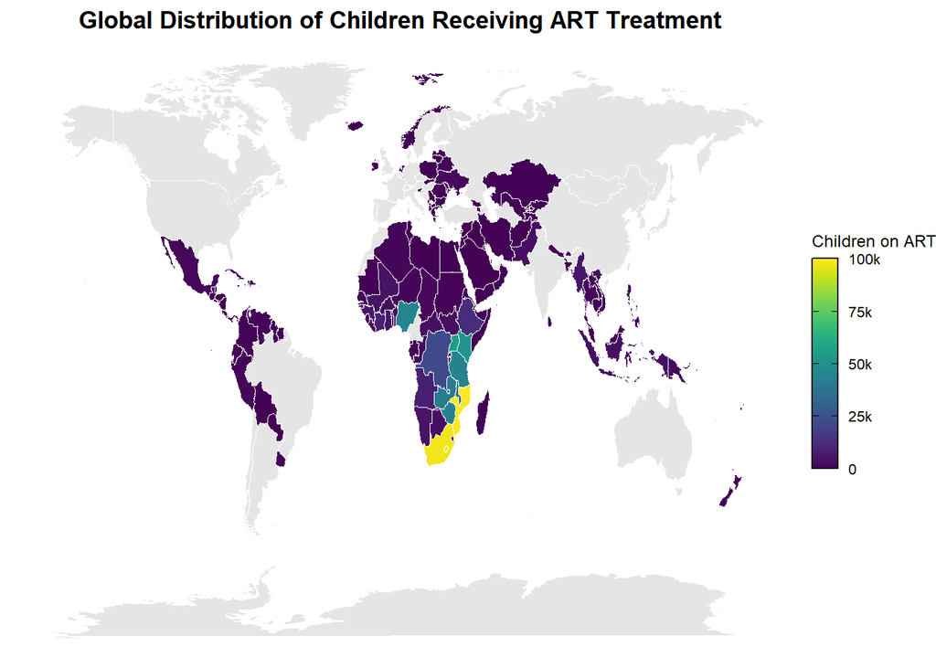

Global distribution of children receiving ART (most recent year available)

```r
latest_art <- art_data %>%
  group_by(country) %>%
  filter(time_period == max(time_period)) %>%
  ungroup()

world_map_data <- map_data("world") %>%
  mutate(
    iso3c = countrycode(
      sourcevar = region,
      origin = "country.name",
      destination = "iso3c",
      warn = FALSE
    )
  ) %>%
  left_join(latest_art, by = c("iso3c" = "alpha_3_code"))

world_map <- ggplot(world_map_data) +
  geom_polygon(
    aes(x = long, y = lat, group = group, fill = obs_value),
    color = "white",
    linewidth = 0.1
  ) +
  scale_fill_viridis(
    name = "Children on ART",
    na.value = "grey90",
    option = "D",
    breaks = c(0, 25000, 50000, 75000, 100000),
    labels = c("0", "25k", "50k", "75k", "100k"),
    guide = guide_colorbar(
      barwidth = unit(0.5, "cm"),
      barheight = unit(4, "cm"),
      ticks.colour = "black",
      frame.colour = "black"
    )
  ) +
  theme_void() +
  labs(title = "Global Distribution of Children Receiving ART Treatment") +
  theme(
    plot.title = element_text(hjust = 0.5, face = "bold"),
    legend.position = "right",
    legend.title = element_text(size = 9),
    legend.text = element_text(size = 8)
  )
world_map
```

The world map highlights significant disparities in ART access for children, with Sub-Saharan Africa showing the highest concentrations. Countries like South Africa, Mozambique, and Uganda appear as hotspots, likely due to higher HIV prevalence and international aid efforts. In contrast, developed nations (North America, Europe, and parts of Asia) show minimal representation, possibly because of lower pediatric HIV rates. The visualization underscores the urgent need for targeted interventions in high-burden regions.

### Top 10 Countries by ART Coverage

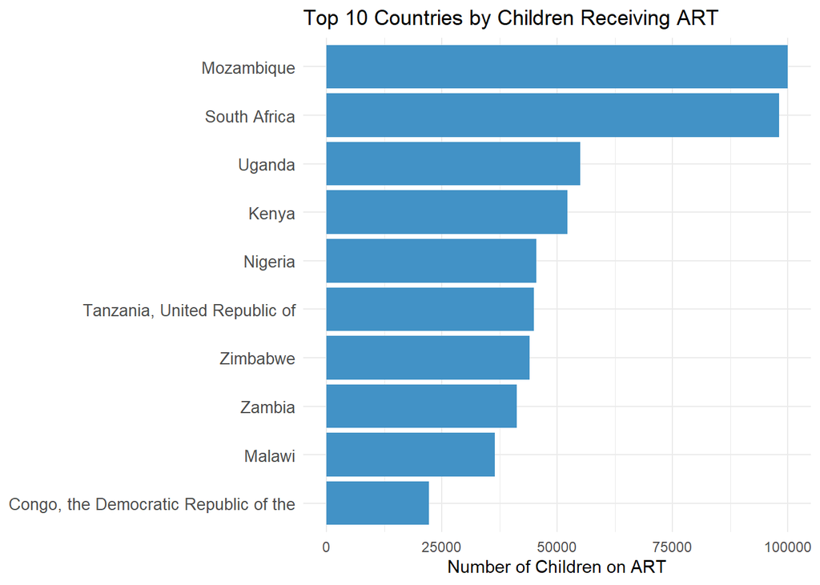

Top 10 countries by number of children receiving ART (most recent year)

```r
top_countries <- art_data %>%
  group_by(country) %>%
  filter(time_period == max(time_period)) %>%
  ungroup() %>%
  top_n(10, obs_value) %>%
  arrange(desc(obs_value))

bar_plot <- ggplot(top_countries, aes(x = reorder(country, obs_value), y = obs_value)) +
  geom_col(fill = "#4292c6") +
  labs(x = NULL, y = "Number of Children on ART",
       title = "Top 10 Countries by Children Receiving ART") +
  coord_flip() +
  theme_minimal() +
  theme(axis.text.y = element_text(size = 10))

bar_plot
```

The bar chart reveals that Mozambique and South Africa lead in absolute numbers of children on ART, reflecting their high HIV burden and scaled-up treatment programs. East and Southern African nations (Uganda, Kenya, Zimbabwe) dominate the list, aligning with WHO priority regions. Notably, the Democratic Republic of Congo ranks lower despite its large population, suggesting gaps in healthcare access. The data emphasizes the success of ART programs in certain countries but highlights inequities in others.

### Relationship Between GDP and ART Access

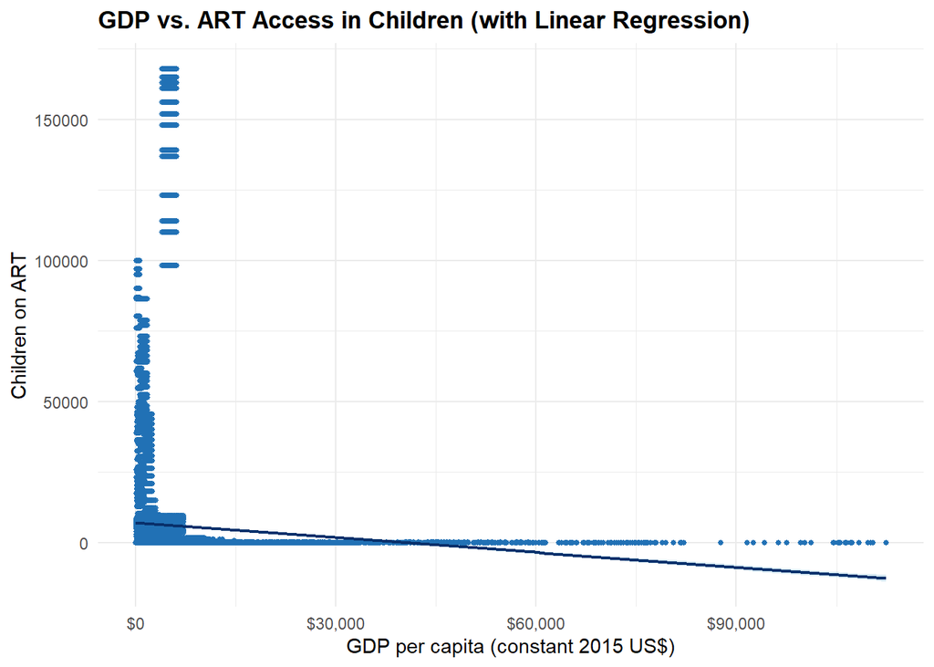

Relationship between GDP per capita and children’s ART access with linear regression

```r
scatter_data <- merged_data %>%
  drop_na(`GDP per capita (constant 2015 US$)`, obs_value)

scatter_plot <- ggplot(scatter_data,
       aes(x = `GDP per capita (constant 2015 US$)`, y = obs_value)) +

  geom_point(alpha = 0.6, color = "#2171b5", size = 1) +


  geom_smooth(method = "lm",
              formula = y ~ x,
              color = "#08306b",
              fill = "#9ecae1",
              se = TRUE,
              linewidth = 0.8) +

  scale_x_continuous(labels = dollar) +
  labs(x = "GDP per capita (constant 2015 US$)",
       y = "Children on ART",
       title = "GDP vs. ART Access in Children (with Linear Regression)") +
  theme_minimal() +
  theme(plot.title = element_text(face = "bold"))

scatter_plot
```